# Data Analysis Pipeline and Preliminary Results

Cuisine Authenticity

Author

Analysis Report

Published

August 13, 2026

## 1. Introduction

The primary analytical goal is to evaluate how sociodemographic factors, cultural capital (Education, Parental Education, Childhood Arts), and ideological leanings (e.g., Social and Economic Conservatism) influence these tastes across the rating scale.

## 2. Data Preparation and Reshaping

The data pipeline begins with raw survey data.

1. **Recoding and Cleaning**:
   - Demographic variables (age, education, income, gender, race) are cleaned and transformed.
   - Continuous predictors like **Social Conservatism (`social_c`)**, **Economic Conservatism (`economic_c`)**, **Education (`educ_c`)**, **Parental Education (`peduc_c`)**, **Childhood Arts (`arts_c`)**, **Income (`income_c`)**, and **Age (`age_c`)** are mean-centered and scaled. Centering ensures that the model intercepts represent the “average” survey respondent, aiding in convergence and interpretation.
2. **Long-Format Reshaping**:
   - To leverage multilevel modeling, the separate genre rating columns are pivoted into a “long” dataset. Each row represents a single respondent’s rating of a single genre.
   - This structure allows the model to treat both `respondent_id` and `genre` as grouping variables (random effects), controlling for individual response tendencies and baseline differences between genres.

## 3. Modeling Strategy: Bayesian Adjacent Category (ACAT) Models

Because the outcome is a 1-to-7 ordinal scale, standard linear regression is inappropriate (it assumes the conceptual “distance” between a 1 and 2 is identical to a 6 and 7). Instead, we utilize **Bayesian Multilevel Ordinal Models** via the `brms` package.

We selected the **Adjacent Category (ACAT)** family. Unlike cumulative ordinal models, ACAT models predict the probability of choosing category $k+1$ rather than category $k$. This aligns conceptually with how survey respondents make step-by-step decisions on a Likert scale.

### Structural Model Hierarchy

We systematically fitted a hierarchy of competing model specifications to the data:

1. **Baseline Strict (Model 1):** Assumes that continuous predictors exert a uniform, linear push across all thresholds of the scale, identical for all genres.
2. **Relaxed Category-Specific (CS) (Model 2):** Relaxes the proportional odds assumption using the `cs()` specification. This allows the slope of predictors to vary across each step of the rating scale, capturing non-linear “centrist” or “polarizing” effects.
3. **Random Slopes (RS) Strict (Model 3):** Allows the effect of demographic predictors to vary independently for every genre.
4. **Variance Strict (Distributional) (Model 4):** Introduces a second equation predicting the `disc` parameter (inverse variance/consensus) using demographics, testing if groups differ in how much they agree on genre ratings.
5. **Variance + Random Slopes (Model 5):** The ultimate hybrid, applying genre-specific random slopes to both the location and the variance equations.
6. **Relaxed CS + Random Slopes (Model 6):** Relaxes slopes for specific categories and genres simultaneously.

## 4. Model Comparison

To determine which mathematical architecture is empirically justified, we compared predictive performance using the **Watanabe-Akaike Information Criterion (WAIC)** subsetted to 1,000 random posterior draws.

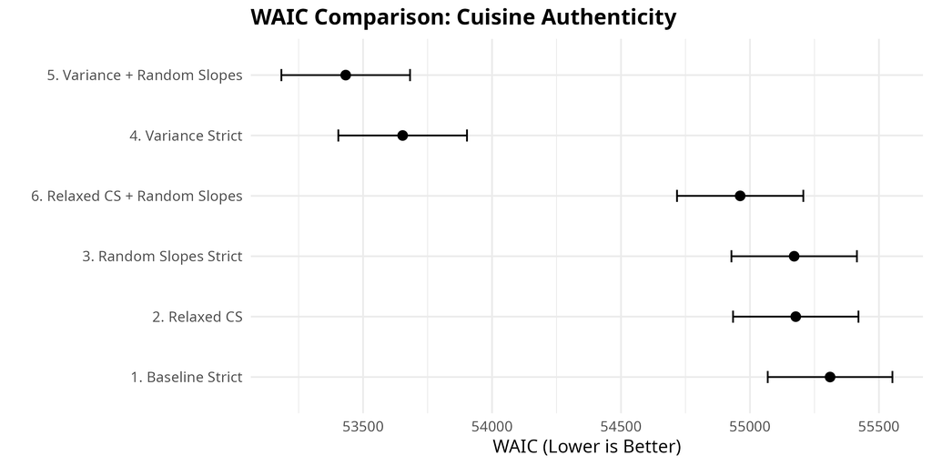

## 5. Preliminary Findings: Baseline and Fixed Effects

### 5.1 Global Demographic Fixed Effects

We extract the global fixed effects from the best-fitting location-scale model. These coefficients represent the average structural “push” of demographic, socialization, and ideological traits across all genres.

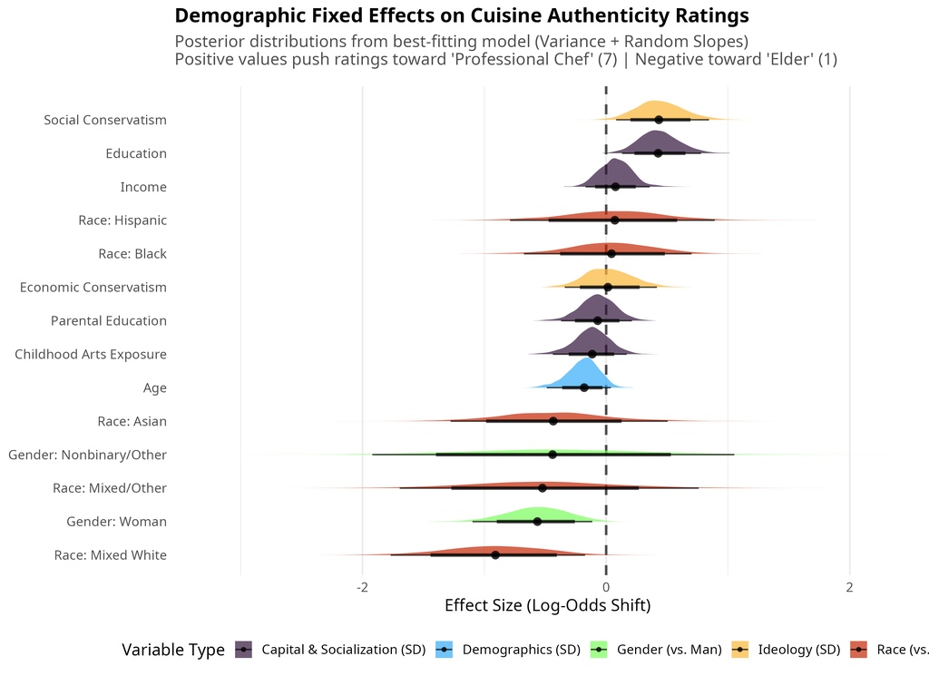

### 5.2 Baseline Preference by Genre

The model estimates a random intercept for each genre. This shows the baseline public preference for each genre, holding demographic and ideological differences constant at their means.

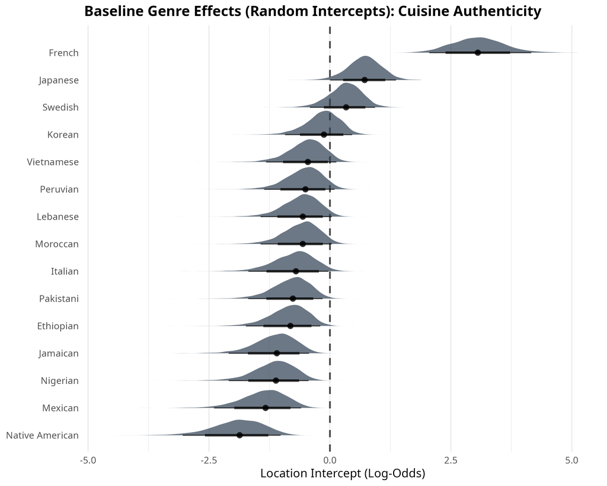

### 5.3 Ideological Effects: Polarization vs. Centrism

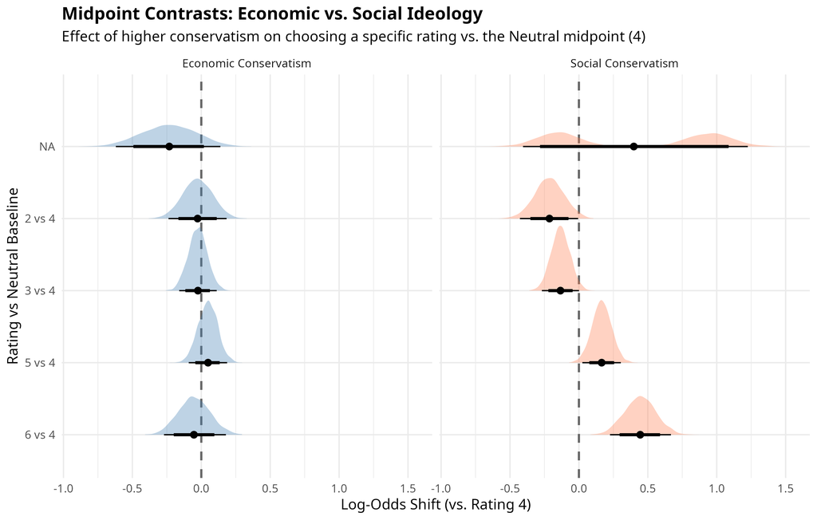

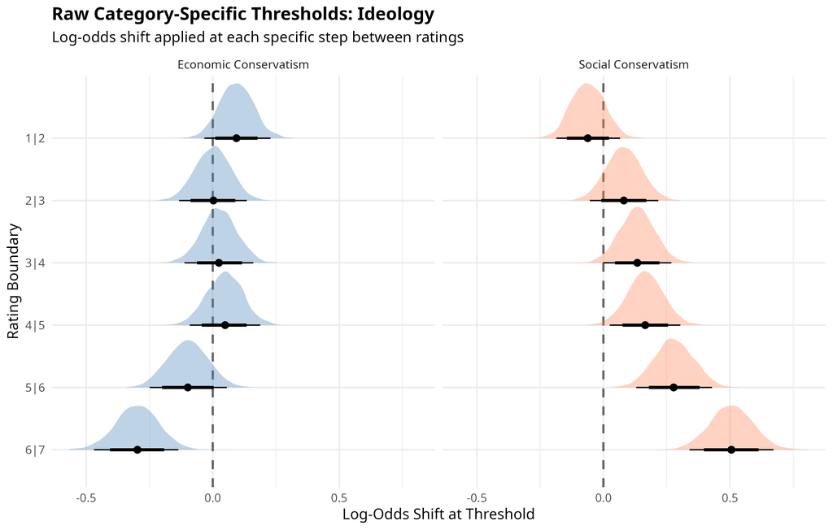

### 5.4 Cultural Capital Effects

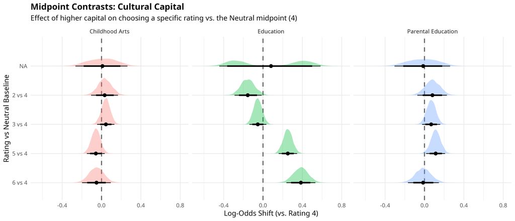

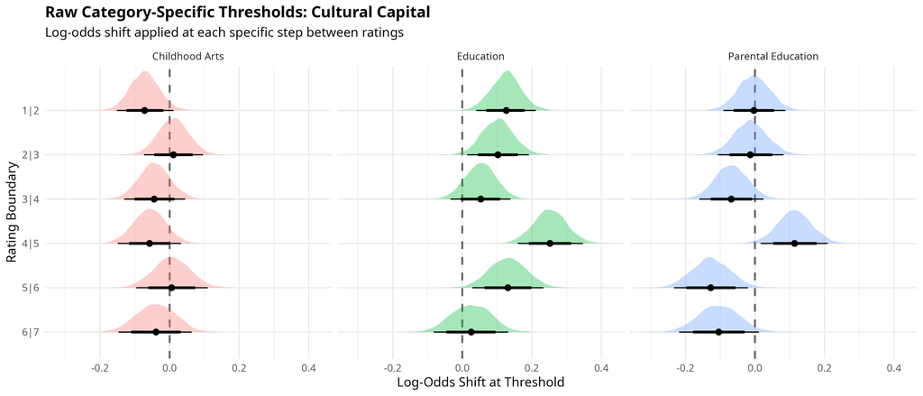

## 6. Random Slopes: Demographic and Ideological Effects by Genre

We estimated models allowing the continuous effects to vary independently for each genre.

### 6.1 Ideological Effects

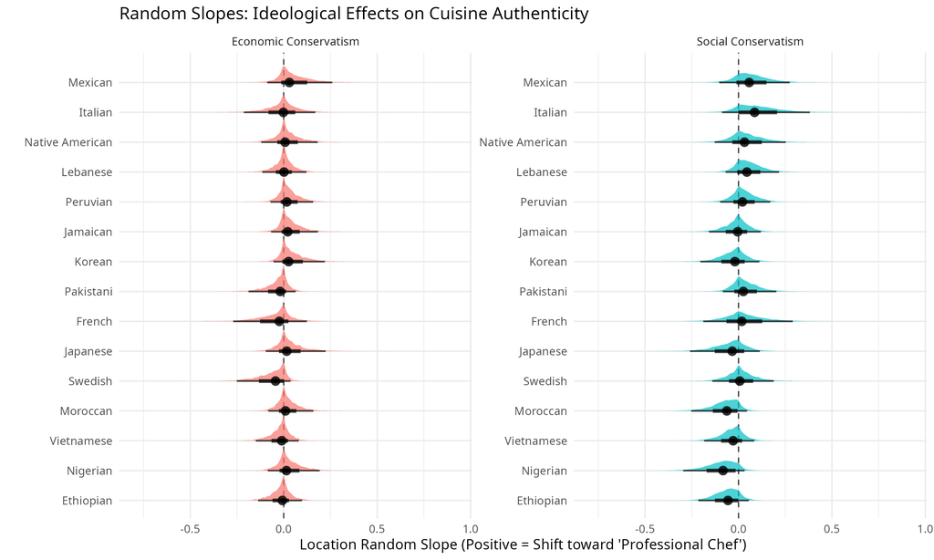

### 6.2 Cultural Capital Effects

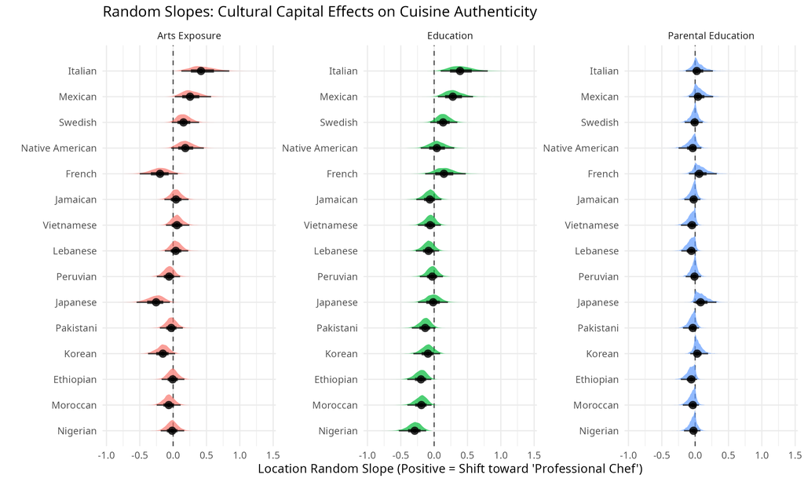

## 7. Cultural Consensus and Variance (Distributional Model)

To answer the question of whether there is widespread public agreement (consensus) vs. polarization (high variance) on these genre ratings, we look at the results of the **Distributional (Location-Scale) ACAT Model**.

### 7.1 Baseline Variance by Genre

By extracting both the location intercept and the `disc` parameter intercept, we can map the entire landscape in two dimensions: baseline likability (Location) and how much the public agrees on it (Consensus).

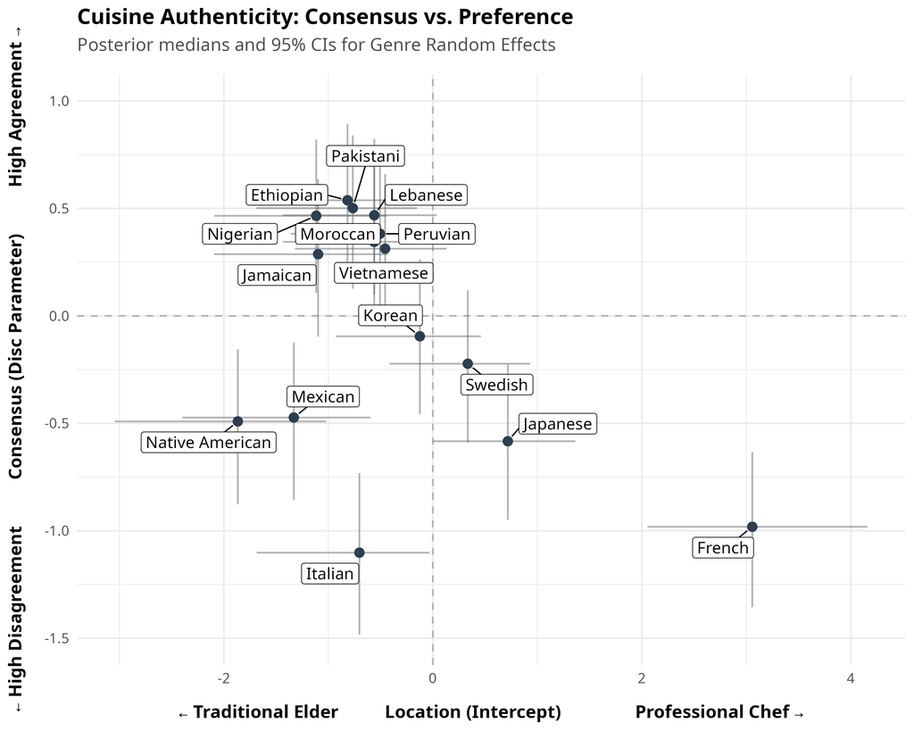

- **Higher `disc` parameters** mean higher consensus (lower variance).
- **Lower `disc` parameters** (negative) mean lower consensus (more chaotic, polarized, or spread-out ratings).

### 7.2 Demographic Effects on Global Consensus

Do certain demographic groups have stronger consensus than others? The following plot visualizes the probability distribution of the demographic effects on the global `disc` (consensus) parameter.

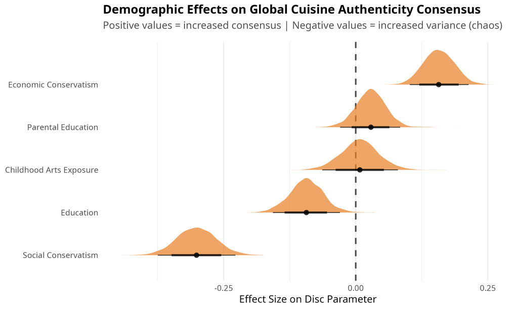

**Key Insights into Consensus:** * A negative estimate means that higher values of the predictor are associated with lower consensus (greater variance/chaos in ratings). * A positive estimate means that the trait increases consensus (ratings are tighter/more uniform).

## 8. Random Slopes for Consensus: How Demographic Effects on Variance Change by Genre

Just as demographic pulls on the rating itself differ by genre, we also evaluated whether demographic impacts on *variance* differ by genre using Model 5 (Variance + Random Slopes).

- A **negative value** means the trait lowers consensus (increases variance/chaos) for that specific genre.
- A **positive value** means the trait increases consensus (decreases variance).

### 8.1 Ideological Effects on Consensus

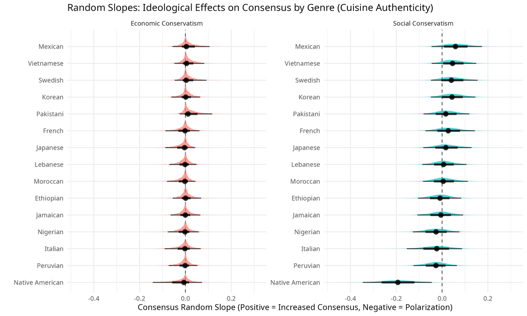

### 8.2 Cultural Capital Effects on Consensus

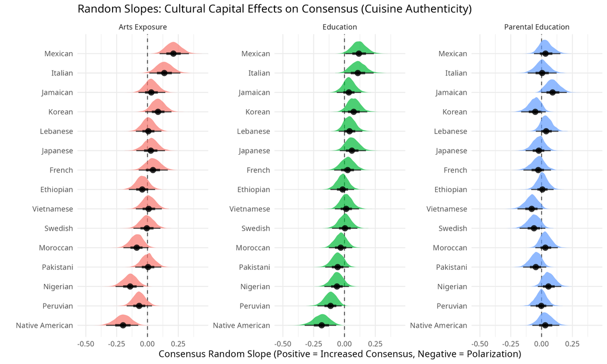

## 9. Conclusion

By systematically scaling up from baseline strict location models to fully distributional location-scale models with random slopes, we successfully map the social structure of taste.

1. Model fit comparisons overwhelmingly mandate the use of **Variance (Distributional)** components combined with **Random Slopes**.
2. Sociodemographic characteristics not only shift *which* genres respondents prefer, but critically alter the *variance and consensus* of those preferences across the public landscape.